# Final Project Report

### Visualization 2

**Scatter Plot for data visualization**

```r
library(hrbrthemes)
```

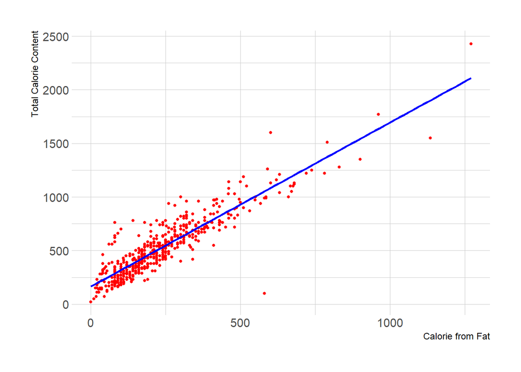

```r
my_plot<-ggplot(fastfood, aes(x=cal_fat, y=calories)) +  geom_point(size=1, color="red") + geom_smooth(method=lm , color="blue", se=FALSE) +
  theme_ipsum() + xlab("Calorie from Fat") +ylab("Total Calorie Content")
my_plot
```

Reference: https://r-graph-gallery.com/274-map-a-variable-to-ggplot2-scatterplot.html https://r-graph-gallery.com/50-51-52-scatter-plot-with-ggplot2.html

Above chart is a scatter plot that indicates the relationship between total calorie content of each food item in each restaurant and their calorie contribution from total fat. This graph indicates a positive relationship. It supports the alternative hypothesis of higher amount of total fat content results higher total calorie content in fast foods. Moreover, calorie content of most of food items from fat ranges within 0 to 500 kcal and total calorie content spreads 0 to 1000 kcal.

**Statistical Test to Find out Correlation between Total Calorie Content and Total Calorie from Fat**

Calculating a single correlation

```r
fastfood$calories
```

```
##   [1]  380  840 1130  750  920  540  300  510  430  770  380  620  530  700  250
##  [16]  290  640  580  740  350  380  480  580  520  680  570  530  530  670  560
##  [31]  730  690  630  800  370  480  760 1210 1510 2430  180  270  440  890 1770
##  [46]  640  960 1600  140  270  490  190  320  490  220  350  520  430  310  270
##  [61]  120  230  350  470  500  130  190  260  390  970  490  440   70  110  140
##  [76]  210  430  450  500  450  540  350  860  720  710  640  340  410  380  450
##  [91]  600  870  640  650  740  710  720  800 1280 1120 1130 1220 1120  450  450
## [106]  450  610  680  430  570  450  280  470  740 1000 1350  380  560  350  610
## [121]  970 1080 1190  330  440  550  730  100  370  430  410  340  320  500  210
## [136]  830  320  330  400  450  630  650  690  690  540  650  690  550  540  360
## [151]  510  640  480  710  740  750  610  300  680  710  840  240  360  600  680
## [166]  550  710  520  800  620  740  590  600  430  650 1030  730  470  980  290
## [181]  290  220  210  240  300  240  200   70  430  420  230  720 1550 1000  330
## [196]  290 1040  730 1100  300  520  450  360  900  580 1220  260  550  990  940
## [211]  310 1250  730  970 1100  770  900  990  660  760  340  380  590  720  550
```

[output cut: 20 more lines]

```r
fastfood$cal_fat
```

```
##   [1]   60  410  600  280  410  250  100  210  190  400  170  300  180  300   70
##  [16]   50  330  190  310  130  160  200  300  160  280  200  200  240  320  180
##  [31]  300  340  200  320  190  250  390  630  790 1270  100  140  240  480  960
##  [46]  240  360  600   70   80  250  110  120  250   90  100  230  144   54   99
##  [61]   54  108  153  207  207   54   81  110  162  414  170  171   18   27   36
##  [76]   45  108  117  162  171  225  126  423  279  380  330  150  220  200  250
##  [91]  350  530  330  340  430  380  380  480  830  680  680  780  680  130  130
## [106]  130  270  350  180  300  220  130  220  350  550  900  190  290  150  270
## [121]  410  460  510  140  190  240  350  580  160  180  230  170  160  240  100
## [136]  490  160  100   90  180  290  300  280  280  220  280  310  230  210  120
## [151]  210  290  220  390  350  330  270   80  360  410  400  100  150  250  280
## [166]  260  260  240  310  310  320  250  310  160  320  459  252  180  495  120
## [181]  110   80   70   90  150   90   60   45  220  340  120  480 1134  585  140
## [196]  120  630  351  675  130  280  230  160  486  300  720   90  250  585  567
## [211]  110  738  387  549  666  432  510  580  360  430  170  210  360  450  330
```

[output cut: 20 more lines]

```r
cor.test ( fastfood$calories , fastfood$cal_fat )
```

```
##
##  Pearson's product-moment correlation
##
## data:  fastfood$calories and fastfood$cal_fat
## t = 47.225, df = 513, p-value < 2.2e-16
## alternative hypothesis: true correlation is not equal to 0
## 95 percent confidence interval:
##  0.8841381 0.9166513
## sample estimates:
##       cor
## 0.9016612
```

The relationship between the total calorie content and total calorie from fat was significant, r(513)=0.9, p= less than 2.2e-16. As the correlation was positive, this indicates that increase in calorie from fat is related to an increment in total calorie.

Reference: https://www.adelaide.edu.au/mathslearning/system/files/media/documents/2021-07/Correlations-in-R.pdf

## Conclusion

As a conclusion,

- There is no significant difference between total calorie content between McDonalds and BurgerKing restaurants.
- There is a strong positive relationship between total calorie content and calorie from total fat of fast foods.
- Though, I planned to use a stacked bar plot for visualization 1, it was not success because I used only one categorical variable with two numerical variables. Hence, I plotted a bar plot for data visualization.